# Практика 19 · Від згортки до уваги> Лекція: lecture.html · Тест: quiz.html ·> Домашнє завдання: homework.html> ⏱ **Цей зошит нічого не навчає.** Заміряно: **18 с** на вільній машині й **37 с**> на зав

## Замір 4 · Головний факт теми: увага не бачить порядкуПереставмо токени на вході. Якщо увага **еквіваріантна щодо перестановки**, товихід від перемішаного входу має точно дорівнювати перемішаному виходу відзвичайного входу.Порівняємо три операції на одному й тому самому вході:* увагу без позиційного кодування,* увагу з позиційним кодуванням,* згортку по послідовності токенів (`Conv1d` із ядром 3).

```python
def sinusoid_positions(n_tokens, dim):
    """Класичне синусоїдальне кодування: жодного параметра, чиста формула."""
    position = torch.arange(n_tokens).unsqueeze(1).float()
    step = torch.arange(0, dim, 2).float()
    angle = position / torch.pow(10000.0, step / dim)
    table = torch.zeros(n_tokens, dim)
    table[:, 0::2] = torch.sin(angle)
    table[:, 1::2] = torch.cos(angle)
    return table.unsqueeze(0)


position_code = sinusoid_positions(TOKENS, DIM)

torch.manual_seed(0)
attention_layer = nn.MultiheadAttention(DIM, HEADS, batch_first=True)
conv_layer = nn.Conv1d(DIM, DIM, kernel_size=3, padding=1)


def run_attention(t):
    with torch.no_grad():
        return attention_layer(t, t, t, need_weights=False)[0]


def run_conv(t):
    # Conv1d чекає (батч, канали, довжина), а токени лежать (батч, довжина, канали)
    with torch.no_grad():
        return conv_layer(t.transpose(1, 2)).transpose(1, 2)


generator = torch.Generator().manual_seed(7)
shuffle = torch.randperm(TOKENS, generator=generator)

plain_normal = run_attention(tokens)
plain_shuffled = run_attention(tokens[:, shuffle, :])
gap_plain = (plain_shuffled - plain_normal[:, shuffle, :]).abs().max().item()

coded_normal = run_attention(tokens + position_code)
coded_shuffled = run_attention(tokens[:, shuffle, :] + position_code)
gap_coded = (coded_shuffled - coded_normal[:, shuffle, :]).abs().max().item()

conv_normal = run_conv(tokens)
conv_shuffled = run_conv(tokens[:, shuffle, :])
gap_conv = (conv_shuffled - conv_normal[:, shuffle, :]).abs().max().item()

print("перестановка (перші 10 позицій):", shuffle[:10].tolist(), "...")
print("масштаб самого виходу          :", round(plain_normal.abs().max().item(), 4))
print()
print(f"увага БЕЗ позиційного кодування: {gap_plain:.3e}   ← нуль із точністю float32")
print(f"увага З позиційним кодуванням  : {gap_coded:.4f}")
print(f"згортка Conv1d(3)              : {gap_conv:.4f}")
```

```
перестановка (перші 10 позицій): [19, 5, 3, 23, 17, 48, 44, 36, 11, 10] ...
масштаб самого виходу          : 0.8192

увага БЕЗ позиційного кодування: 1.788e-07   ← нуль із точністю float32
увага З позиційним кодуванням  : 0.1353
згортка Conv1d(3)              : 1.7000
```

### Що з цього виходить для класифікаціїАбстракція стає відчутною на двох картинках. Візьмемо маленьку фігуру у**верхньому лівому** куті та її ж у **нижньому правому**. Друга отримана з першоїчистою перестановкою патчів: жоден піксель не змінився, змінилися лише місця.Проженемо обидві через увагу, усереднимо 49 виходів і подамо в лінійнийкласифікатор. Без позиційного кодування він **не зможе їх розрізнити** — і цене питання навчання чи кількості даних.

```
БЕЗ ПОЗИЦІЙНОГО: найбільша різниця логітів 5.960e-08
З ПОЗИЦІЙНИМ : найбільша різниця логітів 4.322e-02
```

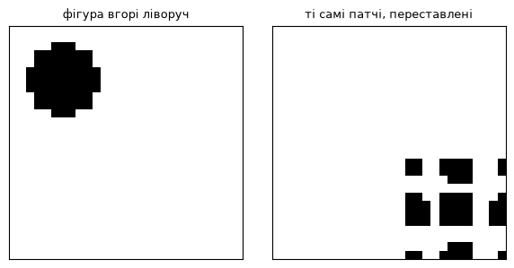

```python
torch.manual_seed(0)
classifier = nn.Linear(DIM, len(SHAPE_NAMES))

blank = np.zeros((28, 28), dtype=np.float32)
yy, xx = np.mgrid[0:28, 0:28]
blank[((yy - 6) ** 2 + (xx - 6) ** 2) < 20] = 1.0     # кружечок угорі ліворуч

top_left = to_patches(blank)
# поворот сітки патчів на 180°: та сама фігура опиняється внизу праворуч
rotate = np.arange(49).reshape(7, 7)[::-1, ::-1].reshape(-1)
bottom_right = top_left[rotate]


def logits_of(patch_rows, with_position):
    with torch.no_grad():
        x = token_norm(patch_projection(torch.tensor(patch_rows))).unsqueeze(0)
        if with_position:
            x = x + position_code
        return classifier(run_attention(x).mean(dim=1))[0].numpy()


for with_position in (False, True):
    a = logits_of(top_left, with_position)
    b = logits_of(bottom_right, with_position)
    label = "З ПОЗИЦІЙНИМ " if with_position else "БЕЗ ПОЗИЦІЙНОГО"
    print(f"{label}: найбільша різниця логітів {np.abs(a - b).max():.3e}")

fig, axes = plt.subplots(1, 2, figsize=(6, 3))
for ax, rows, title in zip(axes, [top_left, bottom_right],
                           ["фігура вгорі ліворуч", "ті самі патчі, переставлені"]):
    ax.imshow(rows.reshape(7, 7, 4, 4).transpose(0, 2, 1, 3).reshape(28, 28), cmap="gray_r")
    ax.set_title(title, fontsize=9)
    ax.set_xticks([]); ax.set_yticks([])
plt.tight_layout(); plt.show()
```

## Замір 5 · Навіщо ділити на √dСкалярний добуток двох випадкових векторів довжини `d` має дисперсію рівно `d`.Отже, з ростом розмірності оцінки збігу роздуваються, softmax насичуєтьсяй починає віддавати всю вагу одному елементу.Поміряємо чотири величини для розмірностей 4, 16, 64 і 256:* **дисперсію** самих оцінок;* **найбільшу вагу** в рядку після softmax;* **ентропію** рядка — наскільки розподіл розмазаний (максимум `ln 49 ≈ 3.892`);* **суму `p·(1−p)`** — наскільки softmax узагалі здатний пропустити градієнт.

```python
def softmax_row_stats(logits):
    """Максимальна вага, ентропія рядка й здатність пропускати градієнт."""
    probabilities = torch.softmax(logits, dim=-1)
    top = probabilities.max(dim=-1).values.mean().item()
    entropy = (-(probabilities * torch.log(probabilities + 1e-12)).sum(-1)).mean().item()
    # p(1-p) — діагональ якобіана softmax: коли вона коло нуля, градієнт не йде
    slope = (probabilities * (1 - probabilities)).sum(-1).mean().item()
    return top, entropy, slope


torch.manual_seed(0)
SAMPLES = 200

print(f"{'d':>5} {'дисперс.':>9} {'макс без':>9} {'макс з':>8} "
      f"{'ентроп. без':>12} {'ентроп. з':>10} {'нахил без':>10} {'нахил з':>8} "
      f"{'у скільки гірше':>8}")
for dim in (4, 16, 64, 256):
    q = torch.randn(SAMPLES, TOKENS, dim)
    k = torch.randn(SAMPLES, TOKENS, dim)
    raw = q @ k.transpose(1, 2)
    scaled_logits = raw / math.sqrt(dim)

    top_raw, ent_raw, slope_raw = softmax_row_stats(raw)
    top_sc, ent_sc, slope_sc = softmax_row_stats(scaled_logits)

    print(f"{dim:>5} {raw.var().item():>9.2f} {top_raw:>9.3f} {top_sc:>8.3f} "
          f"{ent_raw:>12.3f} {ent_sc:>10.3f} {slope_raw:>10.3f} {slope_sc:>8.3f} "
          f"{slope_sc / slope_raw:>8.1f}")

print()
print("рядків у вибірці       :", SAMPLES * TOKENS)
print("рівномірна вага (1/49) :", round(1 / TOKENS, 4))
print("максимальна ентропія   :", round(math.log(TOKENS), 3))
```

```
    d  дисперс.  макс без   макс з  ентроп. без  ентроп. з  нахил без  нахил з у скільки гірше
```

```
    4      3.99     0.300    0.123        2.599      3.442      0.827    0.948      1.1
   16     16.06     0.599    0.126        1.284      3.427      0.534    0.949      1.8
   64     63.96     0.798    0.126        0.555      3.427      0.281    0.950      3.4
```

```
  256    255.50     0.903    0.127        0.249      3.425      0.138    0.950      6.9

рядків у вибірці       : 9800
рівномірна вага (1/49) : 0.0204
максимальна ентропія   : 3.892
```

Прочитай другу колонку: дисперсія збігається з `d` до другого знака — теоріяпідтверджена. Далі головне: без ділення при `d = 256` один елемент забираєблизько 90 % ваги рядка з 49, а здатність пропускати градієнт падає майжевсемеро. З діленням усі три величини стоять на місці при будь-якій розмірності.## Замір 6 · Скільки коштує увага в параметрахМатриць чотири: `W_q`, `W_k`, `W_v` і вихідна, кожна `d × d` плюс зсув на `d`чисел. Разом `4·d² + 4·d`. Найцікавіше — що це число **не залежить від кількостіголів**: голови ділять ті самі матриці, а не додають нові.

```python
print(f"{'d':>5} {'голів':>6} {'розмір голови':>14} {'ручний рахунок':>15} "
      f"{'sum(p.numel())':>15} {'збіг':>6}")
for dim in (32, 64, 768):
    for heads in (1, 2, 4, 8, 12):
        if dim % heads:
            continue
        block = nn.MultiheadAttention(dim, heads, batch_first=True)
        measured = sum(p.numel() for p in block.parameters())
        by_hand = 4 * dim * dim + 4 * dim
        assert by_hand == measured, "формула розійшлася з бібліотекою!"
        print(f"{dim:>5} {heads:>6} {dim // heads:>14} {by_hand:>15,} "
              f"{measured:>15,} {'так':>6}".replace(",", " "))

print()
print("✅ 4·d² + 4·d збігається з sum(p.numel()) у всіх випадках")
```

```
    d  голів  розмір голови  ручний рахунок  sum(p.numel())   збіг
   32      1             32           4 224           4 224    так
   32      2             16           4 224           4 224    так
   32      4              8           4 224           4 224    так
   32      8              4           4 224           4 224    так
   64      1             64          16 640          16 640    так
   64      2             32          16 640          16 640    так
   64      4             16          16 640          16 640    так
   64      8              8          16 640          16 640    так
```

```
  768      1            768       2 362 368       2 362 368    так
  768      2            384       2 362 368       2 362 368    так
  768      4            192       2 362 368       2 362 368    так
  768      8             96       2 362 368       2 362 368    так
```

```
  768     12             64       2 362 368       2 362 368    так

✅ 4·d² + 4·d збігається з sum(p.numel()) у всіх випадках
```

### Чи справді голови дивляться в різні місцяПорахуємо, скільки різних цілей (позицій із найбільшою вагою) дають голови длякожного токена, і наскільки корельовані їхні матриці уваги.

```python
carrier = tokens + position_code

print(f"{'голів':>6} {'розмір голови':>14} {'різних цілей':>13} {'кореляція голів':>16}")
for heads in (1, 2, 4, 8, 16):
    torch.manual_seed(11)
    block = nn.MultiheadAttention(DIM, heads, batch_first=True)
    with torch.no_grad():
        _, per_head = block(carrier, carrier, carrier,
                            need_weights=True, average_attn_weights=False)
    per_head = per_head[0]                      # (голів, токенів, токенів)

    best = per_head.argmax(dim=-1)
    distinct = sum(len(set(best[:, i].tolist())) for i in range(TOKENS)) / TOKENS

    if heads > 1:
        flat = per_head.reshape(heads, -1)
        flat = flat - flat.mean(dim=1, keepdim=True)
        norm = flat.norm(dim=1, keepdim=True)
        matrix = (flat @ flat.T) / (norm @ norm.T)
        # середнє по недіагональних клітинках: наскільки голови схожі між собою
        off_diagonal = ((matrix.sum() - matrix.diag().sum()) / (heads * heads - heads)).item()
        shown = f"{off_diagonal:>16.3f}"
    else:
        shown = f"{'—':>16}"

    print(f"{heads:>6} {DIM // heads:>14} {distinct:>13.2f}{shown}")
```

```
 голів  розмір голови  різних цілей  кореляція голів
     1             32          1.00               —
     2             16          1.98          -0.042
     4              8          3.94          -0.012
     8              4          7.00          -0.011
    16              2         12.29          -0.008
```

## Замір 6б · Скільки коштує геометрія справжньому ViTРаз увага не бачить порядку, положення доводиться дописувати окремою таблицею«номер патча → вектор». Подивимось, скільки вона важить у справжній моделі.Беремо `vit_b_16` із `torchvision` з `weights=None` — нічого не завантажується,модель просто збирається з випадковими вагами, а нам потрібні лише розміри.

```python
from torchvision.models import vit_b_16

vit = vit_b_16(weights=None)
total_weights = sum(p.numel() for p in vit.parameters())
position_weights = vit.encoder.pos_embedding.numel()

print("ViT-B/16, усього ваг    :", f"{total_weights:,}".replace(",", " "))
print("позиційне кодування     :", f"{position_weights:,}".replace(",", " "),
      "  форма", tuple(vit.encoder.pos_embedding.shape))
print("це", f"{100 * position_weights / total_weights:.3f} %", "усієї моделі")
print()
# 197 позицій = 196 патчів 16×16 на кадрі 224×224 плюс один службовий токен
print("перевірка рахунком: 197 × 768 =", 197 * 768)
assert position_weights == 197 * 768, "розклад позиційного кодування не зійшовся!"
print("✅ уся геометрія моделі — оці 0.175 % ваг")
```

```
ViT-B/16, усього ваг    : 86 567 656
позиційне кодування     : 151 296   форма (1, 197, 768)
це 0.175 % усієї моделі

перевірка рахунком: 197 × 768 = 151296
✅ уся геометрія моделі — оці 0.175 % ваг
```

## Замір 7 · Ціна росте квадратичноМатриця уваги має `n²` клітинок, тож множень у ній `2·n²·d` (оцінки збігу плюсзважена сума значень). Проєкції коштують `4·n·d²` і ростуть **лінійно**.Порахуємо обидва числа для різних розмірів патча — і знайдемо точку, де вониміняються місцями.

```python
print(f"{'патч':>7} {'токенів':>8} {'пар уваги':>10} {'множень: матриця':>17} "
      f"{'множень: проєкції':>18}")
for patch in (14, 7, 4, 2):
    n = (FRAME // patch) ** 2
    matrix_cost = 2 * n * n * DIM
    projection_cost = 4 * n * DIM * DIM
    print(f"{str(patch) + '×' + str(patch):>7} {n:>8} {n * n:>10} "
          f"{matrix_cost:>17,} {projection_cost:>18,}".replace(",", " "))

print()
print("рівновага 2n²d = 4nd² настає при n = 2d =", 2 * DIM, "токенів")
```

```
   патч  токенів  пар уваги  множень: матриця  множень: проєкції
  14×14        4         16             1 024             16 384
    7×7       16        256            16 384             65 536
    4×4       49       2401           153 664            200 704
    2×2      196      38416         2 458 624            802 816

рівновага 2n²d = 4nd² настає при n = 2d = 64 токенів
```

Тепер те саме годинником. Заміряємо прямий прохід `nn.MultiheadAttention` прирізній кількості токенів. Беремо **мінімум** із семи прогонів, а не середнє:мінімум менше залежить від того, чим ще зайнята машина.

```python
timed_layer = nn.MultiheadAttention(64, 4, batch_first=True).eval()

print(f"{'токенів':>8} {'пар':>10} {'мс':>9} {'час × від 49':>13} {'пар × від 49':>13}")
baseline = None
for n_tokens in (49, 196, 784, 1568, 3136):
    sample = torch.randn(1, n_tokens, 64)
    repeats = max(3, int(2000 / n_tokens))
    with torch.no_grad():
        for _ in range(5):                      # прогріваємо, щоб не міряти перший виклик
            timed_layer(sample, sample, sample, need_weights=False)
        runs = []
        for _ in range(7):
            started = time.perf_counter()
            for _ in range(repeats):
                timed_layer(sample, sample, sample, need_weights=False)
            runs.append((time.perf_counter() - started) / repeats * 1000)
    fastest = min(runs)
    if baseline is None:
        baseline = (fastest, n_tokens * n_tokens)
    print(f"{n_tokens:>8} {n_tokens * n_tokens:>10} {fastest:>9.3f} "
          f"{fastest / baseline[0]:>13.1f} {n_tokens * n_tokens / baseline[1]:>13.1f}")
```

```
 токенів        пар        мс  час × від 49  пар × від 49
      49       2401     0.125           1.0           1.0
     196      38416     0.575           4.6          16.0
```

```
     784     614656     7.739          62.0         256.0
```

```
    1568    2458624    45.668         366.0        1024.0
```

```
    3136    9834496   240.813        1929.8        4096.0
```

```
найбільша вага в рядку, у середньому: 0.0339
рівномірна вага 1/49               : 0.0204
ентропія рядка                     : 3.863 з максимальних 3.892
це 99.3 % від ідеально рівномірного розподілу
```

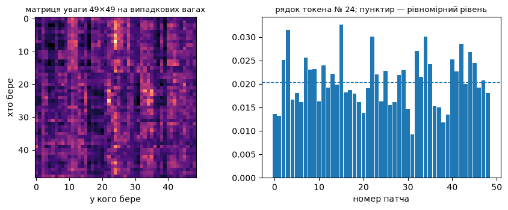

```python
torch.manual_seed(0)
fresh = nn.MultiheadAttention(DIM, HEADS, batch_first=True)
with torch.no_grad():
    _, attention_map = fresh(carrier, carrier, carrier,
                             need_weights=True, average_attn_weights=True)
attention_map = attention_map[0].numpy()

row_entropy = -(attention_map * np.log(attention_map + 1e-12)).sum(axis=1).mean()
uniform_weight = 1 / TOKENS

print("найбільша вага в рядку, у середньому:", round(attention_map.max(axis=1).mean(), 4))
print("рівномірна вага 1/49               :", round(uniform_weight, 4))
print("ентропія рядка                     :", round(row_entropy, 3),
      "з максимальних", round(math.log(TOKENS), 3))
print("це", f"{100 * row_entropy / math.log(TOKENS):.1f} %", "від ідеально рівномірного розподілу")

fig, axes = plt.subplots(1, 2, figsize=(9, 3.6))
axes[0].imshow(attention_map, cmap="magma")
axes[0].set_title("матриця уваги 49×49 на випадкових вагах", fontsize=9)
axes[0].set_xlabel("у кого бере"); axes[0].set_ylabel("хто бере")
axes[1].bar(range(TOKENS), attention_map[24], width=0.9)
axes[1].axhline(uniform_weight, linestyle="--", linewidth=1)
axes[1].set_title("рядок токена № 24; пунктир — рівномірний рівень", fontsize=9)
axes[1].set_xlabel("номер патча")
plt.tight_layout(); plt.show()
```

Ентропія коло 99 % від максимальної означає, що до навчання увага розмазанамайже рівномірно. Красиві карти уваги зі статей — це результат навчання, а невластивість самої операції.## Підсумок

```python
print("Що ми довели без жодного навчання:")
print()
print(f"  1. згортці 3×3 треба {layers_needed} шарів на кадр 28×28, увазі — один")
print(f"  2. ручний рахунок збігається з бібліотекою до {np.abs(output - library_output).max():.1e}")
print(f"  3. власна реалізація на numpy збігається до {np.abs(ours - reference).max():.1e}")
print(f"  4. перестановка: увага {gap_plain:.1e}, з кодуванням {gap_coded:.3f}, "
      f"згортка {gap_conv:.3f}")
print("  5. без ділення на √d softmax при d = 256 віддає ~90 % ваги одному елементу")
print("  6. параметрів 4d² + 4d при будь-якій кількості голів")
print(f"  7. позиційне кодування ViT-B/16 — {position_weights} ваг, "
      f"{100 * position_weights / total_weights:.3f} % моделі")
print()
print("час виконання зошита:", round(time.perf_counter() - notebook_started, 1), "с")
```

```
Що ми довели без жодного навчання:

  1. згортці 3×3 треба 13 шарів на кадр 28×28, увазі — один
  2. ручний рахунок збігається з бібліотекою до 2.0e-07
  3. власна реалізація на numpy збігається до 5.6e-08
  4. перестановка: увага 1.8e-07, з кодуванням 0.135, згортка 1.700
  5. без ділення на √d softmax при d = 256 віддає ~90 % ваги одному елементу
  6. параметрів 4d² + 4d при будь-якій кількості голів
  7. позиційне кодування ViT-B/16 — 151296 ваг, 0.175 % моделі

час виконання зошита: 12.8 с
```

## Завдання### 🟢 Рівень 1Заміни фігуру в наскрізному прикладі (`draw_shape(1, rng)` → інший клас) іповтори замір перестановки. Переконайся, що число «без позиційного кодування»лишається на рівні `1e-07` незалежно від картинки, а число для згортки міняється.### 🟡 Рівень 2Додай до заміру 5 розмірність `d = 1024` і побудуй графік «найбільша вагав рядку від `d`» для обох варіантів — з діленням і без. Признач вісь `d`логарифмічною. Поясни словами, чому крива «з діленням» горизонтальна.### 🔴 Рівень 3Допиши `attention_numpy` так, щоб вона приймала **маску**: булеву матрицю`(токенів, токенів)`, де `True` означає «сюди дивитись не можна». Забороненіклітинки перед softmax отримують `-inf`. Перевір на трикутній масці (кожен токенбачить лише себе й попередників), що результат збігається з`nn.MultiheadAttention(..., attn_mask=...)` через `np.allclose`.